# Differential gene expression analysis for dose dependent simulated data

Data Description:

simulated.data is simulated lognormcounts matrix having 2300 genes and 4500 cells. simulated.cell.metadata is the cell metadata matrix having the dose level information for the 4500 cells. There are a total of 9 dose groups with 500 cells each. simulated.gene.metadata is the gene metadata matrix having 2300 rows and 4 columns, where the columns correspond to gene names,model: the model dose response curve that the gene follows and Direction: which states whether the gene is UpRegulated or DownRegulated.

```r
simulated.data <- read.delim("~/Documents/Documents/Summer_2019/Mouse_Liver/Rance/snSeq-DGE/New_Simulations/simDataFinal.lognormcounts.txt")
rownames(simulated.data)<-simulated.data[,1]
simulated.data<-simulated.data[,-1]
simulated.cell.metadata <-read.delim("~/Documents/Documents/Summer_2019/Mouse_Liver/Rance/snSeq-DGE/New_Simulations/simCellMeta.txt")
simulated.gene.metadata <- read.delim("~/Documents/Documents/Summer_2019/Mouse_Liver/Rance/snSeq-DGE/New_Simulations/simGeneMeta.txt")
simulated.gene.metadata<-simulated.gene.metadata[,-1]
```

```r
simulated.data<-read.csv("~/Documents/Documents/Summer_2019/Mouse_Liver/Rance/snSeq-DGE/simulatedCorrectProportions/norm_sim_correctprop.txt", sep="")
simulated.cell.metadata<-read.csv("~/Documents/Documents/Summer_2019/Mouse_Liver/Rance/snSeq-DGE/simulatedCorrectProportions/sim_correctprop_cellMeta.txt", sep="")
simulated.gene.metadata<-read.csv("~/Documents/Documents/Summer_2019/Mouse_Liver/Rance/snSeq-DGE/simulatedCorrectProportions/sim_correctprop_geneMeta.txt", sep="")
```

```
Removed 3148 rows containing non-finite values (stat_bin).
```

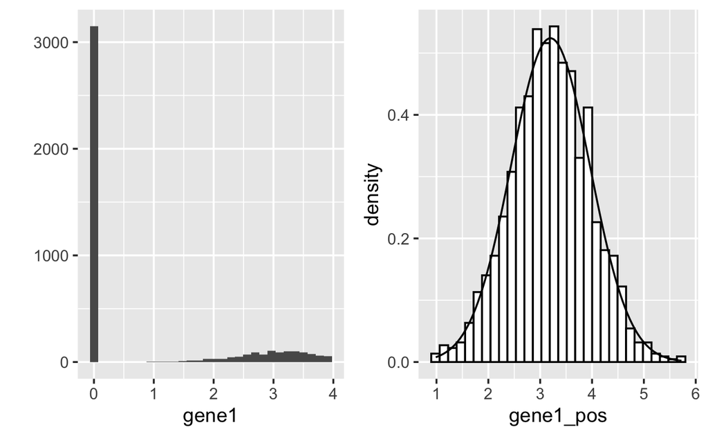

```r
library(data.table)
library(ggplot2)
simulated.data_df <-as.data.table(t(simulated.data))
k0<-qplot(gene1, data = simulated.data_df[gene1  <
                    quantile(as.numeric(simulated.data_df$gene1), probs = .95)])
simulated.data_df<- simulated.data_df[, gene1_pos := ifelse(gene1 > 0, gene1 , NA)]
k1<-ggplot(simulated.data_df, aes(x = gene1_pos)) +
  geom_histogram(aes(y = ..density..), colour = "black", fill = "White") +
  stat_function(fun = dnorm, args = MASS::fitdistr(simulated.data_df[gene1 > 0 ,gene1_pos ], "normal")$estimate)
ggpubr::ggarrange(k0,k1,ncol=2,nrow=1)
```

```r
dose_level<-factor(simulated.cell.metadata$doses)
simulated.data_dose<-data.frame(t(simulated.data),
                                              simulated.cell.metadata[,"doses"])
colnames(simulated.data_dose)[ncol(simulated.data_dose)]<-"Dose"
```

```r
data<-rep(list(data.frame()), nlevels(dose_level))
names(data)<-levels(dose_level)
for(i in levels(dose_level))
{
data[[i]]<- subset(simulated.data_dose
                   , Dose == i, select = gene1 : gene2300)
##data[[i]] is a list of all the seperate dose gene*cell matrices
data[[i]][] <- lapply(data[[i]], function(x) as.numeric(as.character(x)))
data[[i]]<-t(data[[i]])
}
```

```r
# Identify the genes expressed in less than 5% of the cells over all the dose groups
propor<-sapply(data,function(x) apply(x,1,function(x) length(which(x!=0))/length(x)))
b<-which(apply(propor,1,function(x) all(x>0.05))== TRUE)
#Filter out genes
data<-lapply(data,function(x) apply(x,2,function(x) x[b]))
simulated.gene.metadata<-as.data.frame(simulated.gene.metadata[b,])
```

Create data for applying LRT_multiple_groups

```r
data_short<-rep(list(data.frame()),length(data))
data_ind<-lapply(data, function(x) ifelse(x>0,1,0))
#data_ind_short<-lapply(data_ind, function(x) x[x!=0])
data_short<-lapply(data, function(x) apply(x,1,function(x) x[x!=0]))
gene_names<-vector()
for(j in 1:nrow(data[["0"]]))
{
  gene_names[j]<-sprintf("gene%i",j)
}
out<-rep(list(list()),times=nrow(data[["0"]]))
for(j in 1:nrow(data[["0"]]))
{
    xx<-noquote(sprintf("gene%i",j))
    l1<-list(data_short[["0"]][j][[xx]],
             data_short[["0.01"]][j][[xx]],data_short[["0.03"]][j][[xx]],
                      data_short[["0.1"]][j][[xx]],
                      data_short[["0.3"]][j][[xx]],data_short[["1"]][j][[xx]],
                          data_short[["3"]][j][[xx]],data_short[["10"]][j][[xx]],
                                  data_short[["30"]][j][[xx]])
    l2<-list(data_ind[["0"]][j,],data_ind[["0.01"]][j,],
                                  data_ind[["0.03"]][j,],data_ind[["0.1"]][j,],
                                  data_ind[["0.3"]][j,],data_ind[["1"]][j,],
                                  data_ind[["3"]][j,],data_ind[["10"]][j,],
                                  data_ind[["30"]][j,])
    out[[j]]<-LRT_multiple_groups(l1,l2)

}
```

Prior selection under alternative hypothesis

```r
library(matrixStats)
m<-vector()
sigma_mean<-vector()
sigma_var<-vector()
omega_mean<-vector()
omega_var<-vector()
for(i in  levels(dose_level))
{
  #Dose group specific mean of expression levels for all genes
  m[i]<-mean(rowMeans(replace(data[[i]], data[[i]] == 0, NA), na.rm = TRUE),na.rm = TRUE)
  #Dose group specific SD's for all genes
  sigma_mean[i]<-mean(rowVars(replace(as.matrix(data[[i]]),as.matrix(data[[i]]) == 0, NA), na.rm = TRUE),na.rm = TRUE)
  sigma_var[i]<-var(rowVars(replace(as.matrix(data[[i]]),as.matrix(data[[i]]) == 0, NA), na.rm = TRUE),na.rm = TRUE)
  #Dose group specific mean dropout proportions for all genes
  omega_mean[i]<-mean(apply(data[[i]],1,function(x) length(which(x==0))/length(x)))
  omega_var[i]<-var(apply(data[[i]],1,function(x) length(which(x==0))/length(x)))
}
#Choose the scaling constant tau_mu
tau_t_mu = tau_c_mu = tau_mu = c(0.5,1,2,3)
tau_k_mu<-rep(1,9)
#Use sigma_mean and sigma_var to solve for b_sigma and a_sigma
b_sigma = 1
a_sigma = 6
#Use mean and variance of omega to solve for a_w and b_w
#We keep the same values of a_w and b_w for all groups since the omega mean and omega SD values are more or less consistent.
a_w = a_t_w = 0.8 #t refers to the treatment groups
b_w = b_t_w = 0.2
#length(which(simulated.gene.metadata$Category == "Positive"))
prior_Alter<-c(1-((0.78)^(1/1800)),0.01,0.05,0.1, 0.2,0.3,0.4,0.5)
prior_Null<- 1-prior_Alter
```